# Avaliação Continuada - Aula 7

**Execute a célula a seguir para importar as bibliotecas de que vamos precisar e criar a variável `taxis` com nossa base de dados.**

```python
# Importando a biblioteca seaborn
import seaborn as sns
import matplotlib.pyplot as plt

# Carregando a base de dados 'taxis'
taxis = sns.load_dataset("taxis")

# Essa linha cria uma nova coluna
# Você não precisa se preocupar com ela no momento
taxis["pickup_hour"] = taxis["pickup"].dt.hour

taxis.head(2)
```

|  | pickup | dropoff | passengers | distance | fare | tip | tolls | total | color | payment | pickup_zone | dropoff_zone | pickup_borough | dropoff_borough | pickup_hour |
| --- | --- | --- | --- | --- | --- | --- | --- | --- | --- | --- | --- | --- | --- | --- | --- |
| 0 | 2019-03-23 20:21:09 | 2019-03-23 20:27:24 | 1 | 1.60 | 7.0 | 2.15 | 0.0 | 12.95 | yellow | credit card | Lenox Hill West | UN/Turtle Bay South | Manhattan | Manhattan | 20 |
| 1 | 2019-03-04 16:11:55 | 2019-03-04 16:19:00 | 1 | 0.79 | 5.0 | 0.00 | 0.0 | 9.30 | yellow | cash | Upper West Side South | Upper West Side South | Manhattan | Manhattan | 16 |

### Sobre os dados

No exercício de hoje, vamos praticar a customização de gráficos. Vamos partir das seguintes variáveis:

- `pickup_hour`: hora em que a viagem foi iniciada.
- `tip`: valor da gorjeta dada ao motorista.
- `color`: cor do táxi.

Vamos continuar trabalhando quase de onde paramos no exercício anterior, buscando a melhor forma de representar o que encontramos.

Você começará trabalhando do gráfico abaixo:

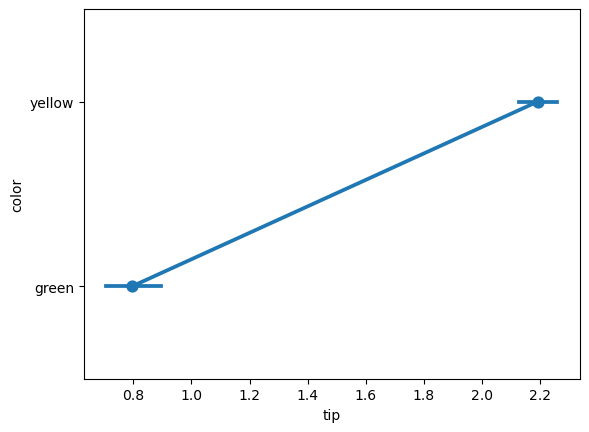

```python
# Escreva sua resposta abaixo
sns.pointplot(
    x="tip",
    y="color",
    data=taxis
)
```

# Exercício de hoje - Parte 1

Você deve alterar o gráfico anterior para mudar três aspectos:

1. Remover a linha que liga os pontos. Você pode fazer isso passando uma string vazia para o argumento `linestyle` da função.
2. Adicionar o indicador ao fim da barra de erro. Você pode fazer isso com o argumento `capsize`. Uma sugestão é usar o valor `0.15`
3. Alterar a barra de erro para que ela exiba o percentil com os 50% centrais dos dados

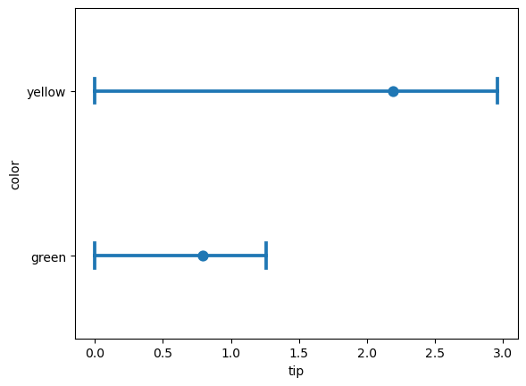

```python
# gabarito

sns.pointplot(
    x="tip",
    y="color",
    data=taxis,
    linestyle="",
    capsize=0.15,
    errorbar=["pi", 50]
)
```

### Exercício de hoje - Parte 2

Agora você deve customizar outro gráfico:

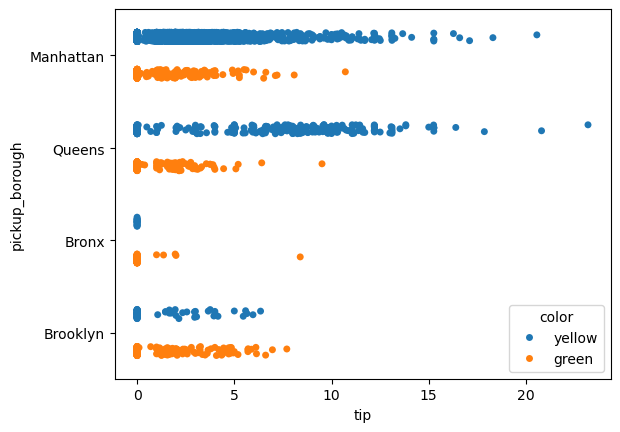

```python
sns.stripplot(
    x="tip",
    y="pickup_borough",
    hue="color",
    dodge=True, # esse argumento faz com que as categories do hue não fiquem sobrepostas
    data=taxis
)
```

Adicione título e rótulos nos eixos, e defina também uma paleta de cores diferente da padrão. Você pode criar a paleta escolhendo cada uma das cores ([veja a lista de cores](https://matplotlib.org/stable/gallery/color/named_colors.html)) ou escolher uma paleta de cores pré-definida.

Veja algumas das paletas que você pode escolher pelo nome:

[figure not shown]

Altere a paleta com o argumento `palette` e defina título e rótulos apropriados para os eixos X e Y.

Se preferir, você pode criar um dicionário para definir sua paleta preenchendo a variável `minha_paleta`.

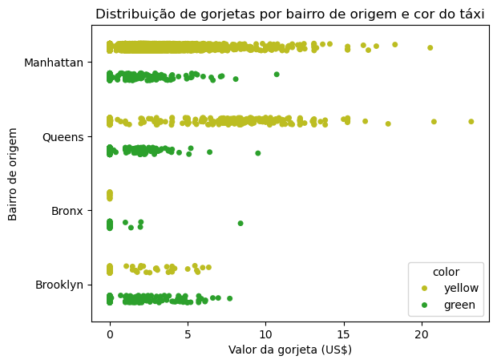

```python
# gabarito
minha_paleta = {"yellow": "tab:olive", "green": "tab:green"}

fig, ax = plt.subplots()

sns.stripplot(
    x="tip",
    y="pickup_borough",
    hue="color",
    dodge=True,
    data=taxis,
    palette=minha_paleta,
    ax=ax
)

ax.set_title("Distribuição de gorjetas por bairro de origem e cor do táxi")
ax.set_xlabel("Valor da gorjeta (US$)")
ax.set_ylabel("Bairro de origem")
```

```python
minha_paleta = {}

fig, ax = plt.subplots()

sns.stripplot(
    x="tip",
    y="pickup_borough",
    hue="color",
    dodge=True,
    data=taxis,

)
```